# data_analysis_for_McManus

Siqi

2024-10-29

## R Markdown

```r
# Load necessary libraries
set.seed(123)
library(ggplot2)
library(splines)
library(minpack.lm)
#install.packages("pracma")
library(pracma)
#install.packages("nls2")
library(nls2)
```

## Including Plots

Data Cleaning and Plotting

```r
# Load and process the
library(readxl)
Data_McManus2_WT_P2L_AAVCremCherry <- read_excel("/Users/angelzhang/Downloads/CircadianProject/Data_McManus2_WT_P2L_AAVCremCherry.xlsx")
```

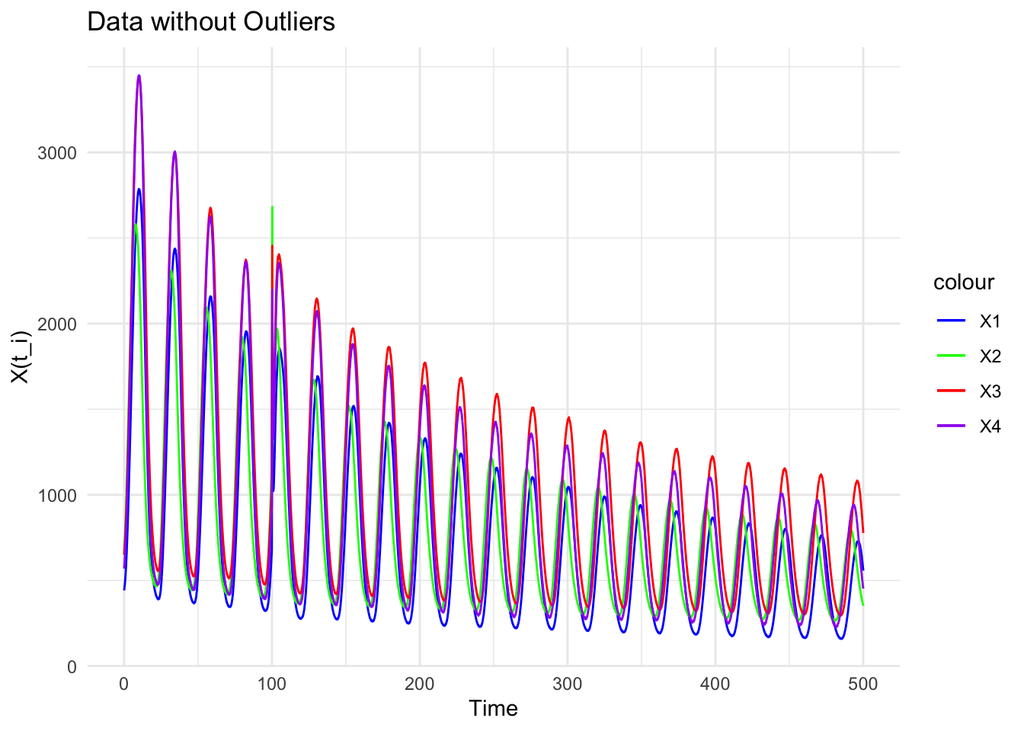

```r
df_MC <- as.data.frame(Data_McManus2_WT_P2L_AAVCremCherry)

# Rename columns for clarity
colnames(df_MC) <- c("Time", "X1", "X2", "X3", "X4")

# Remove outliers where Time is between 100 and 100.1
df_MC <- df_MC[!(df_MC$Time >= 100 & df_MC$Time <= 100.1), ]

# Plot each species
ggplot(df_MC, aes(x = Time)) +
  geom_line(aes(y = X1, color = "X1")) +
  geom_line(aes(y = X2, color = "X2")) +
  geom_line(aes(y = X3, color = "X3")) +
  geom_line(aes(y = X4, color = "X4")) +
  labs(title = "Data without Outliers", x = "Time", y = "X(t_i)") +
  scale_color_manual(values = c("X1" = "blue", "X2" = "green", "X3" = "red", "X4" = "purple")) +
  theme_minimal()
```

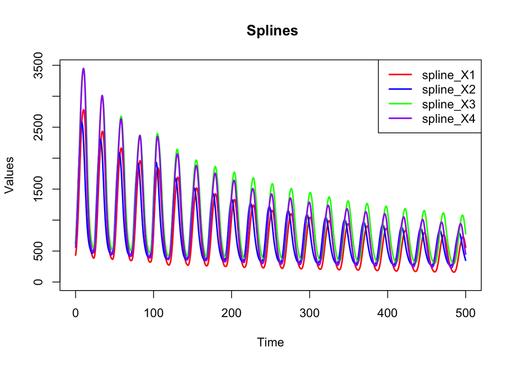

```r
spline_X1 <- predict(smooth.spline(df_MC$Time, df_MC$X1),    spar =)
spline_X2 <- predict(smooth.spline(df_MC$Time, df_MC$X2))
spline_X3 <- predict(smooth.spline(df_MC$Time, df_MC$X3))
spline_X4 <- predict(smooth.spline(df_MC$Time,df_MC$X4))

# Plot the spline-smoothed data
plot(df_MC$Time, spline_X1$y, type = "l", col = "red", lwd = 2,
     xlab = "Time", ylab = "Values", main = " Splines",
     ylim = range(c(spline_X1$y, spline_X2$y, spline_X3$y, spline_X4)))
lines(df_MC$Time, spline_X2$y, col = "blue", lwd = 2)
lines(df_MC$Time, spline_X3$y, col = "green", lwd = 2)
lines(df_MC$Time, spline_X4$y, col = "purple", lwd = 2)

legend("topright", legend = c("spline_X1", "spline_X2", "spline_X3", "spline_X4"),
       col = c("red", "blue", "green", "purple"), lwd = 2)
```

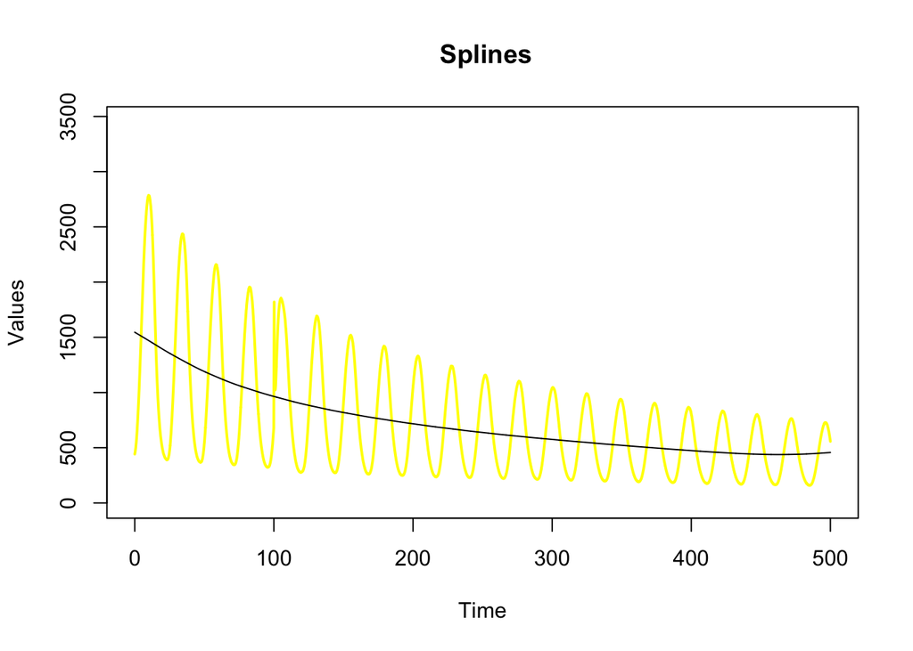

```r
# Plot the spline-smoothed data
spline_X1 <- predict(smooth.spline(df_MC$Time, df_MC$X1, spar=1)) #black line in 2nd #plot（average for X1）

plot(df_MC$Time, df_MC$X1, type = "l", col = "yellow", lwd = 2,
     xlab = "Time", ylab = "Values", main = " Splines",
     ylim = range(c(spline_X1$y, spline_X2$y, spline_X3$y, spline_X4)))
lines(df_MC$Time, spline_X1$y)
```

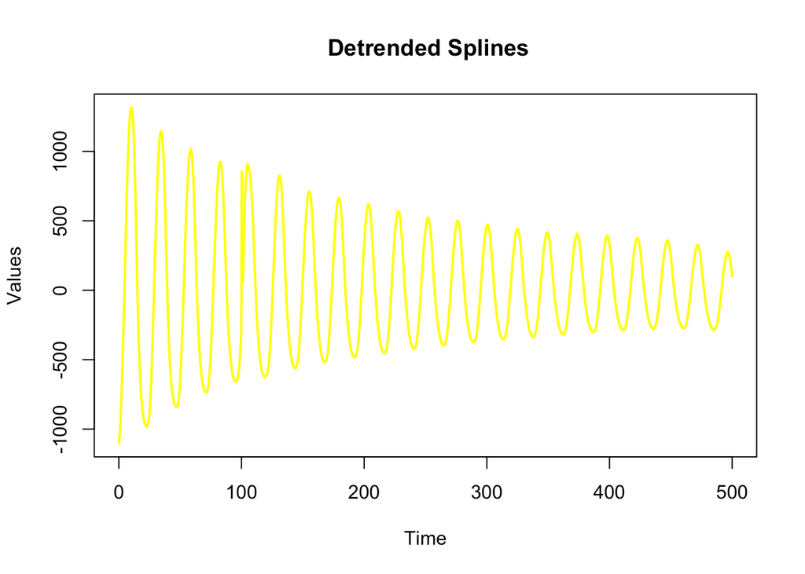

```r
plot(df_MC$Time, df_MC$X1-spline_X1$y, type = "l", col = "yellow", lwd = 2,
     xlab = "Time", ylab = "Values", main = " Detrended Splines")
```

```r
x <- 1:length(df_MC$Time)
y <- df_MC$X1-spline_X1$y

maxima <- findpeaks(df_MC$X1-spline_X1$y, minpeakheight=0)
minima <- findpeaks(-df_MC$X1-spline_X1$y, minpeakheight=0)

x_max <- maxima[,2]
y_max <- maxima[,1]


fit <- nls(y_max ~ a * exp(-b * x_max) + c, start = list(a = max(y_max), b = 0.01, c = min(y_max)))

summary(fit)
```

```
##
## Formula: y_max ~ a * exp(-b * x_max) + c
##
## Parameters:
##    Estimate Std. Error t value Pr(>|t|)
## a 1.115e+03  9.552e+00  116.69   <2e-16 ***
## b 5.000e-04  1.421e-05   35.18   <2e-16 ***
## c 2.142e+02  1.051e+01   20.37   <2e-16 ***
## ---
## Signif. codes:  0 '***' 0.001 '**' 0.01 '*' 0.05 '.' 0.1 ' ' 1
##
## Residual standard error: 21.65 on 98 degrees of freedom
##
## Number of iterations to convergence: 13
## Achieved convergence tolerance: 5.184e-06
```

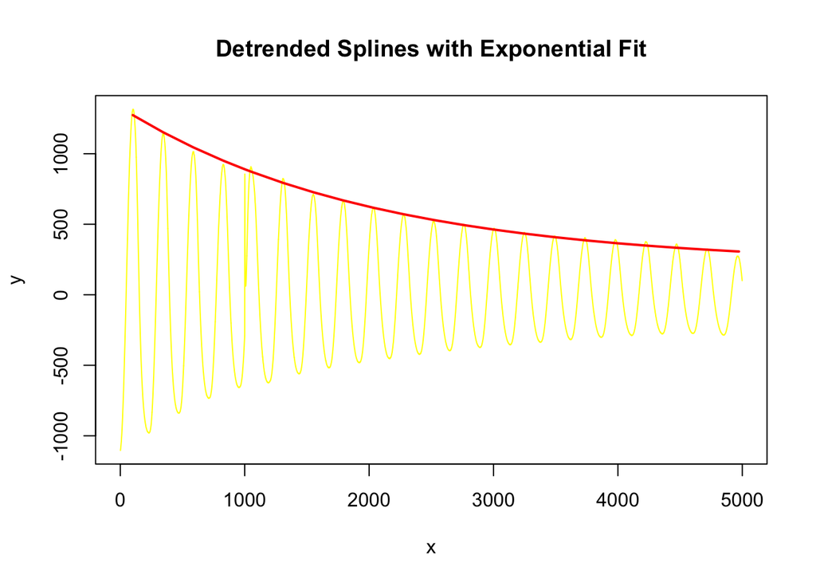

```r
a <- coef(fit)["a"]
b <- coef(fit)["b"]
c <- coef(fit)["c"]

plot(x, y, type="l", col="yellow", main="Detrended Splines with Exponential Fit")
lines(x_max, predict(fit, list(x_max = x_max)), col="red", lwd=2)  #
```

Simulate Data Based on the Fitted Model

```r
t <- seq(0, 100, by = 0.1)

model_function <- function(t, A, gamma, omega, phi, y_shift) {
  A * exp(-gamma * t ) * cos(omega * t + phi) + y_shift
}

# using estimated parameters to def simulating function
simulate_data <- function(t, params, sigma) {
  predicted <- model_function(t, params[1], params[2], params[3], params[4], params[5])
  noise <- rnorm(length(t), mean = 0, sd = sigma)  #using sigma0 to produce noise
  simulated_data <- predicted + noise
  return(simulated_data)
}
sigma0 = 10
param0=c(1000, 0.025, 0.9, 0,0)
simulated_data <- simulate_data(t, param0, sigma0 )
```

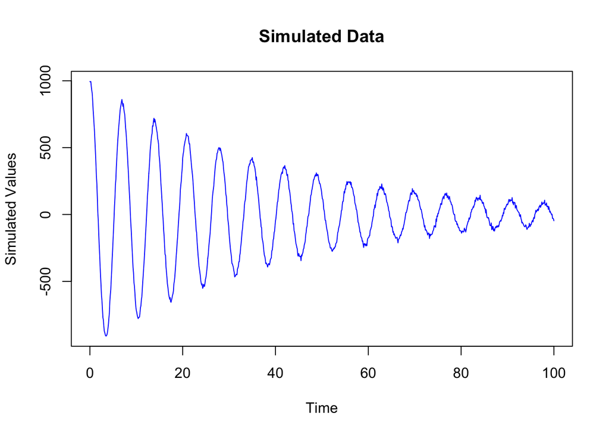

```r
plot(t, simulated_data, type = "l", col = "blue", main = "Simulated Data", xlab = "Time", ylab = "Simulated Values")
```

##Task1 ##generate simulating data 1 time

```r
true_params <- c(A = 1000, gamma = 0.025, omega = 0.9, phi = 0, y_shift = 0)

sigma0 <- 10
t <- seq(0, 100, by = 0.1)
set.seed(123)
y_sim <- model_function(t, true_params[1], true_params[2], true_params[3], true_params[4], true_params[5]) +
         rnorm(length(t), mean = 0, sd = sigma0)

# default algorithm in nls: Gauss-Newton
fit_nls <- nls(
  y_sim ~ model_function(t, A, gamma, omega, phi, y_shift),
  start = list(A = 950, gamma = 0.03, omega = 0.85, phi = 0.1, y_shift = 0), #initial value close to true ones
  data = data.frame(t = t, y_sim = y_sim)
)
#
summary(fit_nls)
```

```
##
## Formula: y_sim ~ model_function(t, A, gamma, omega, phi, y_shift)
##
## Parameters:
##           Estimate Std. Error   t value Pr(>|t|)
## A        1.001e+03  1.447e+00   691.477   <2e-16 ***
## gamma    2.503e-02  5.468e-05   457.732   <2e-16 ***
## omega    9.000e-01  5.483e-05 16413.378   <2e-16 ***
## phi     -2.465e-04  1.459e-03    -0.169    0.866
## y_shift  1.495e-01  3.144e-01     0.475    0.635
## ---
## Signif. codes:  0 '***' 0.001 '**' 0.01 '*' 0.05 '.' 0.1 ' ' 1
##
## Residual standard error: 9.935 on 996 degrees of freedom
##
## Number of iterations to convergence: 9
## Achieved convergence tolerance: 7.293e-06
```

```r
coef(fit_nls)
```

```
##             A         gamma         omega           phi       y_shift
##  1.000598e+03  2.503082e-02  9.000001e-01 -2.464913e-04  1.494642e-01
```

##Task 2 find peaks

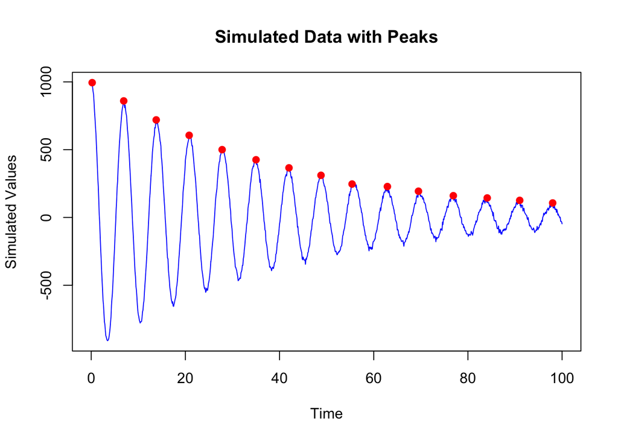

```r
t <- seq(0, 100, by = 0.1)
# find peaks
peaks <- findpeaks(y_sim, minpeakheight = 100, minpeakdistance = 15)

# peaks[, 2] :index of peaks in (1~1000)
#t[ peaks[, 2]]: index of peaks in(1~100)
t_peaks <- t[peaks[, 2]]

y_peaks <- peaks[, 1]

#
plot(t, y_sim, type = "l", col = "blue", main = "Simulated Data with Peaks", xlab = "Time", ylab = "Simulated Values")
points(t_peaks, y_peaks, col = "red", pch = 19)
```

##Finding initial parameters:A and gamma

```r
# transform into log
log_y_peaks <- log(y_peaks)

# logy = -gamma*t + logA
fit_linear <- lm(log_y_peaks ~ t_peaks)

summary(fit_linear)
```

```
##
## Call:
## lm(formula = log_y_peaks ~ t_peaks)
##
## Residuals:
##       Min        1Q    Median        3Q       Max
## -0.096938 -0.017879 -0.002984  0.026874  0.049729
##
## Coefficients:
##              Estimate Std. Error t value Pr(>|t|)
## (Intercept)  6.876027   0.019252  357.16   <2e-16 ***
## t_peaks     -0.022952   0.000335  -68.52   <2e-16 ***
## ---
## Signif. codes:  0 '***' 0.001 '**' 0.01 '*' 0.05 '.' 0.1 ' ' 1
##
## Residual standard error: 0.03923 on 13 degrees of freedom
## Multiple R-squared:  0.9972, Adjusted R-squared:  0.997
## F-statistic:  4694 on 1 and 13 DF,  p-value: < 2.2e-16
```

```r
print("coef:")
```

```
## [1] "coef:"
```

```r
coef(fit_linear)
```

```
## (Intercept)     t_peaks
##  6.87602738 -0.02295209
```

```r
coef(fit_linear)[1]
```

```
## (Intercept)
##    6.876027
```

```r
print("coef:")
```

```
## [1] "coef:"
```

```r
# get log(A)  and  gamma
log_A <- coef(fit_linear)[1]

init_gamma <- -coef(fit_linear)[2] #Extract gamma from the linear fit

cat("log(A) =", log_A, "\n")
```

```
## log(A) = 6.876027
```

```r
cat("gamma =", init_gamma, "\n")
```

```
## gamma = 0.02295209
```

```r
init_A=exp(log_A)
print(init_A)
```

```
## (Intercept)
##    968.7701
```

## to see whether the initial params A and gamma is fitted or not

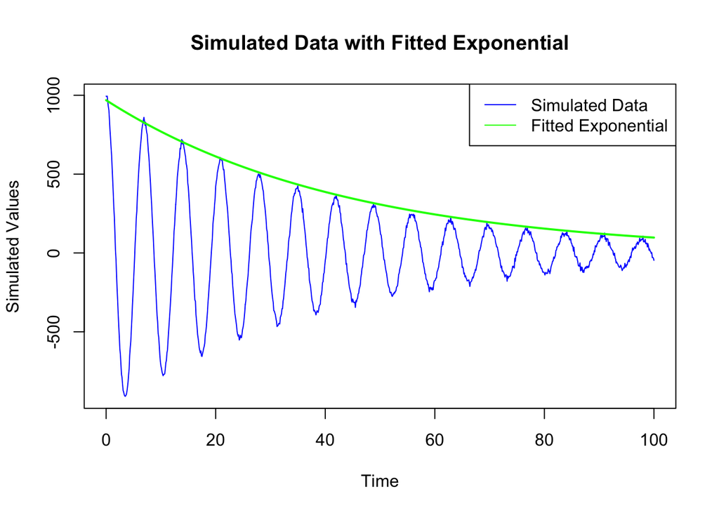

```r
#Plot the simulated data
plot(t, y_sim, type = "l", col = "blue", main = "Simulated Data with Fitted Exponential", xlab = "Time", ylab = "Simulated Values")

# Calculate the fitted exponential curve using estimated A and gamma from the linear model
init_A <- exp(log_A)  # Extract log_A from the linear model

# Add the fitted exponential curve
curve(init_A * exp(-init_gamma * x), from = 0, to = max(t), col = "green", add = TRUE, lwd = 2)
#  Add a legend
legend("topright", legend = c("Simulated Data", "Fitted Exponential"), col = c("blue", "green"), lty = 1)
```

##find initial value：omega

```r
# Extract the time points of the first two consecutive maxima from t_peaks
t_max1 <- t_peaks[1]  # First maximum
t_max2 <- t_peaks[2]  # Second maximum
t_max3 <- t_peaks[3]
t_max4 <- t_peaks[4]
# Calculate the time difference between two consecutive maxima
Delta <- t_max2 - t_max1
Delta
```

```
## [1] 6.7
```

```r
print(t_max3-t_max2)
```

```
## [1] 6.9
```

```r
print(t_max4 - t_max3)
```

```
## [1] 7
```

```r
# Estimate omega (tau) using the formula 2*pi/Delta
init_omega <- 2 * pi / Delta

# Output the result
cat("initial omega (tau) =", init_omega, "\n")
```

```
## initial omega (tau) = 0.9377889
```

```r
cat("Time difference between consecutive maxima (Delta) =", Delta, "\n")
```

```
## Time difference between consecutive maxima (Delta) = 6.7
```

```r
library(nlme)

fit_nls <- nls(
  y_sim ~ model_function(t, A, gamma, omega, phi, y_shift),
  start = list(A = init_A, gamma = init_gamma, omega = init_omega, phi = 0.1, y_shift = 0),
  data = data.frame(t = t, y_sim = y_sim)
)
fit_nls
```

```
## Nonlinear regression model
##   model: y_sim ~ model_function(t, A, gamma, omega, phi, y_shift)
##    data: data.frame(t = t, y_sim = y_sim)
##          A      gamma      omega        phi    y_shift
##  1.001e+03  2.503e-02  9.000e-01 -2.467e-04  1.495e-01
##  residual sum-of-squares: 98312
##
## Number of iterations to convergence: 8
## Achieved convergence tolerance: 5.117e-06
```

###Tasks 3

```r
#library(stats)

simulate_and_estimate <- function(true_params, sigma0 = 10) {

  #simulate data
  t <- seq(0, 100, by = 0.1)


  model_function <- function(t, A, gamma, omega, phi, y_shift) {
    A * exp(-gamma * t) * cos(omega * t + phi) + y_shift
  }


  y_sim <- model_function(t, true_params[1], true_params[2], true_params[3], true_params[4], true_params[5]) +
    rnorm(length(t), mean = 0, sd = sigma0)

  # find initial value
  peaks <- findpeaks(y_sim, minpeakheight = 100, minpeakdistance = 15)
  t_peaks <- t[peaks[, 2]]
  y_peaks <- peaks[, 1]

  log_y_peaks <- log(y_peaks)
  fit_linear <- lm(log_y_peaks ~ t_peaks)
  log_A <- coef(fit_linear)[1]
  init_gamma <- -coef(fit_linear)[2]
  init_A <- exp(log_A)


  Delta <- t_peaks[2] - t_peaks[1]
  init_omega <- 2 * pi / Delta

    # find estimated parameters
  fit_nls <- try(nls(
    y_sim ~ model_function(t, A, gamma, omega, phi, y_shift),
    start = list(A = init_A, gamma = init_gamma, omega = init_omega, phi = 0.1, y_shift = 0),
    data = data.frame(t = t, y_sim = y_sim)
  ), silent = TRUE)

  # check if fitted successful
  if (class(fit_nls) == "try-error") {
    return(NULL)
  }
  # find estmate parameters and standard errors
  param_estimates <- coef(fit_nls)
  cov_matrix <- vcov(fit_nls)

  standard_errors <- sqrt(diag(cov_matrix))
  z_value <- qnorm(0.995)
  conf_intervals <- cbind(
    param_estimates - z_value * standard_errors,
    param_estimates + z_value * standard_errors
  )
  return(list(estimates = param_estimates, conf_intervals = conf_intervals))
}
# test function
true_params <- c(A = 1000, gamma = 0.025, omega = 0.9, phi = 0, y_shift = 0)
result <- simulate_and_estimate(true_params)

result
```

```
## $estimates
##             A         gamma         omega           phi       y_shift
##  9.998168e+02  2.501142e-02  9.000920e-01 -6.547698e-04  4.290222e-01
##
## $conf_intervals
##                  [,1]         [,2]
## A       996.033601870 1.003600e+03
## gamma     0.024868420 2.515441e-02
## omega     0.899948574 9.002353e-01
## phi      -0.004472347 3.162808e-03
## y_shift  -0.393199414 1.251244e+00
```

##Task 3: repeat simulations

```r
# simulat
n_simulations <- 100

#
results <- vector("list", n_simulations)
#
for (i in 1:n_simulations) {
  results[[i]] <- simulate_and_estimate(true_params)
}
results <- Filter(Negate(is.null), results)
null_count <- sum(sapply(results, is.null))
cat("Number of unsuccessful fits (NULL results):", null_count, "\n")
```

```
## Number of unsuccessful fits (NULL results): 0
```

```r
# Initialize coverage counters, one counter for each parameter
coverage_counts <- rep(0, length(true_params))

# Iterate through each simulation result to check coverage.
for (i in 1:length(results)) {
  ci <- results[[i]]$conf_intervals
  for (j in 1:length(true_params)) {
    # Check if it falls within the confidence interval.
    if (true_params[j] >= ci[j, 1] && true_params[j] <= ci[j, 2]) {
      coverage_counts[j] <- coverage_counts[j] + 1
    }
  }
}
#calculate coverage
coverage_proportions <- coverage_counts / n_simulations
# print unsuccessful fits


cat("Coverage for A:", coverage_proportions[1], "\n")
```

```
## Coverage for A: 0.89
```

```r
cat("Coverage for gamma:", coverage_proportions[2], "\n")
```

```
## Coverage for gamma: 0.91
```

```r
cat("Coverage for omega:", coverage_proportions[3], "\n")
```

```
## Coverage for omega: 0.89
```

```r
cat("Coverage for phi:", coverage_proportions[4], "\n")
```

```
## Coverage for phi: 0.89
```

```r
cat("Coverage for y_shift:", coverage_proportions[5], "\n")
```

```
## Coverage for y_shift: 0.91
```

```r
library(tidyverse)
```

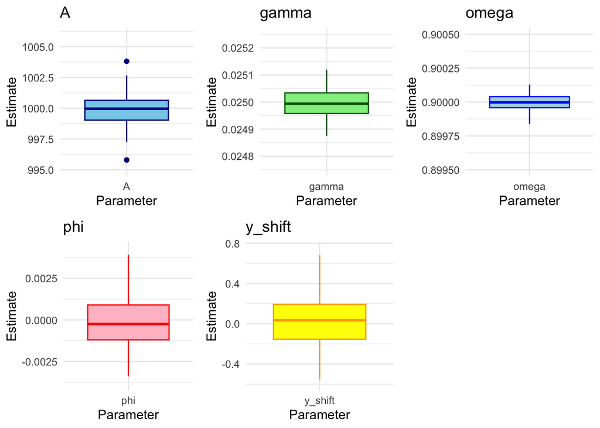

```r
library(dplyr)
library(tidyr)

# Extract valid results (remove NULL values);
valid_results <- Filter(Negate(is.null), results)

# Extract parameter estimates into a data frame
estimate_data <- do.call(rbind, lapply(valid_results, function(res) {
  as.data.frame(t(res$estimates))
}))


colnames(estimate_data) <- c("A", "gamma", "omega", "phi", "y_shift")

estimate_long <- estimate_data %>%
  pivot_longer(cols = everything(), names_to = "Parameter", values_to = "Estimate")

#install.packages("gridExtra")
library(gridExtra) # arange multiple plots
# Create separate boxplots for each parameter with suitable y-axis ranges;
plot_A <- ggplot(estimate_long %>% filter(Parameter == "A"),
                 aes(x = Parameter, y = Estimate)) +
  geom_boxplot(fill = "skyblue", color = "darkblue") +
  labs(title = "A", y = "Estimate") +
  theme_minimal() +
  ylim(995, 1006)

plot_gamma <- ggplot(estimate_long %>% filter(Parameter == "gamma"),
                     aes(x = Parameter, y = Estimate)) +
  geom_boxplot(fill = "lightgreen", color = "darkgreen") +
  labs(title = "gamma", y = "Estimate") +
  theme_minimal() +
  ylim(0.02475, 0.02525)

plot_omega <- ggplot(estimate_long %>% filter(Parameter == "omega"),
                     aes(x = Parameter, y = Estimate)) +
  geom_boxplot(fill = "lightblue", color = "blue") +
  labs(title = "omega", y = "Estimate") +
  theme_minimal() +
  ylim(0.8995, 0.9005)

plot_phi <- ggplot(estimate_long %>% filter(Parameter == "phi"),
                   aes(x = Parameter, y = Estimate)) +
  geom_boxplot(fill = "pink", color = "red") +
  labs(title = "phi", y = "Estimate") +
  theme_minimal() +
  ylim(min(estimate_data$phi) * 0.9, max(estimate_data$phi) * 1.1)

plot_y_shift <- ggplot(estimate_long %>% filter(Parameter == "y_shift"),
                       aes(x = Parameter, y = Estimate)) +
  geom_boxplot(fill = "yellow", color = "orange") +
  labs(title = "y_shift", y = "Estimate") +
  theme_minimal() +
  ylim(min(estimate_data$y_shift) * 0.9, max(estimate_data$y_shift) * 1.1)

# Arrange all subplots into a single large plot.
grid.arrange(plot_A, plot_gamma, plot_omega, plot_phi, plot_y_shift, ncol = 3)
```

This plot indicates that most of the estimated parameters obtained from 100 simulations are close to the true parameters.

##Task 4

finding initial parameters on asymmetric osillator model(on initial meeting file)

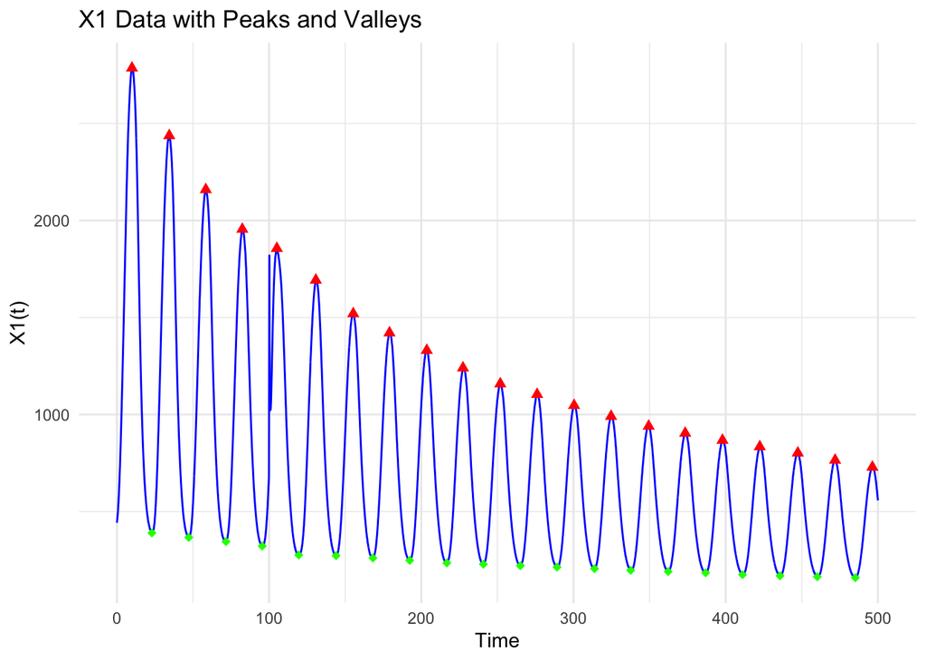

```r
time <- df_MC$Time
X1 <- df_MC$X1
# FInd X1 valleys and peaks
peaks <- findpeaks(X1, minpeakheight = 600, minpeakdistance = 20)
peaks<-peaks[-6, ]
t_peaks <- time[peaks[, 2]]
y_peaks<- peaks[, 1]
#delete outlier

valleys <- findpeaks(-X1, minpeakheight = -500, minpeakdistance = 50)

t_valleys <- time[valleys[, 2]]
y_valleys <- -valleys[, 1]  # restore

#
df_peaks <- data.frame(Time = t_peaks, Value = y_peaks)
df_valleys <- data.frame(Time = t_valleys, Value = y_valleys)


ggplot(df_MC, aes(x = Time, y = X1)) +
  geom_line(color = "blue") +
  geom_point(data = df_peaks, aes(x = Time, y = Value), color = "red", size = 2, shape = 17) +
  geom_point(data = df_valleys, aes(x = Time, y = Value), color = "green", size = 2, shape = 18) +
  labs(title = "X1 Data with Peaks and Valleys",
       x = "Time",
       y = "X1(t)") +
  theme_minimal()
```

```r
log_y_peaks <- log(y_peaks)
log_y_valleys <- log(y_valleys)

fit_peaks <- lm(log_y_peaks ~ t_peaks)
fit_valleys <- lm(log_y_valleys ~ t_valleys)

eta_max <- coef(fit_peaks)[2]  # η_max
eta_min <- coef(fit_valleys)[2]  # η_min

# estimate A_max and A_min
A_max <- exp(coef(fit_peaks)[1])
A_min <- exp(coef(fit_valleys)[1])


Delta <- t_peaks[2] - t_peaks[1]
tau <- 2 * pi / Delta

#assume phi = 0
phi <- 0

# print
cat("Initial A_max:", A_max, "\n")
```

```
## Initial A_max: 2428.445
```

```r
cat("Initial A_min:", A_min, "\n")
```

```
## Initial A_min: 372.6489
```

```r
cat("Initial eta_max:", eta_max, "\n")-
cat("Initial eta_min:", eta_min, "\n")
```

```
## Initial eta_max: -0.002618547
## Initial eta_min: -0.001868607
```

```
## integer(0)
```

```r
cat("Initial tau:", tau, "\n")
```

```
## Initial tau: 0.2564565
```

```r
cat("Initial phi:", phi, "\n")
```

```
## Initial phi: 0
```

##plot fitted curve to compare

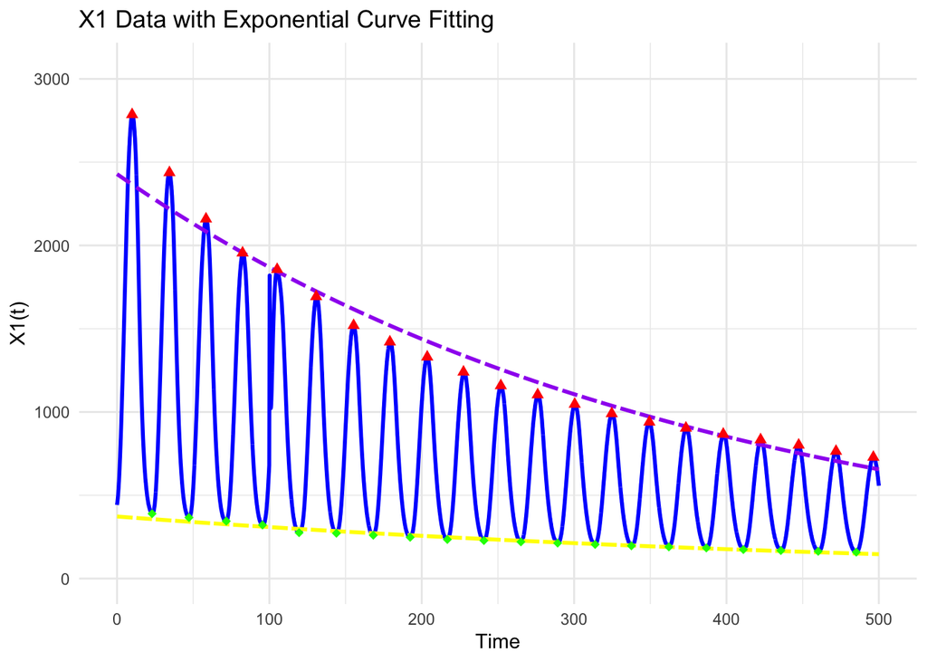

```r
max_exp_curve <- A_max * exp(eta_max * time)
min_exp_curve <- A_min * exp(eta_min * time)
#
df_peaks <- data.frame(Time = t_peaks, Value = y_peaks)
df_valleys <- data.frame(Time = t_valleys, Value = y_valleys)
df_max_exp_curve <- data.frame(Time = time, ExponentialCurve = max_exp_curve)
df_min_exp_curve <- data.frame(Time = time, ExponentialCurve = min_exp_curve)
#
ggplot(df_MC, aes(x = Time, y = X1)) +
  geom_line(color = "blue", size = 1) +  #
  geom_line(data = df_max_exp_curve, aes(x = Time, y = ExponentialCurve), color = "purple", size = 1, linetype = "dashed") +  # expontential curve
  geom_line(data = df_min_exp_curve, aes(x = Time, y = ExponentialCurve), color = "yellow", size = 1, linetype = "dashed") +  # expontential curve
  geom_point(data = df_peaks, aes(x = Time, y = Value), color = "red", size = 2, shape = 17) +  #
  geom_point(data = df_valleys, aes(x = Time, y = Value), color = "green", size = 2, shape = 18) +
  labs(title = "X1 Data with Exponential Curve Fitting",
       x = "Time",
       y = "X1(t)") +
  theme_minimal() +
  scale_y_continuous(limits = c(0, max(X1) * 1.1))  #
```

using lm(),I cannot get a good fit, so I try to use nls to find initial A and gamma：

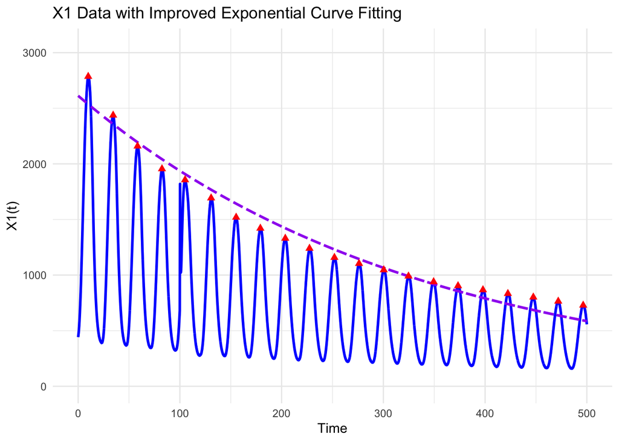

```r
nls_fit <- nls(y_peaks ~ A_max * exp(eta_max * t_peaks),
               start = list(A_max = max(y_peaks), eta_max = -0.01),
               control = nls.control(maxiter = 100))


A_max <- coef(nls_fit)["A_max"]
eta_max <- coef(nls_fit)["eta_max"]

# generate curve
exp_curve <- A_max * exp(eta_max * time)


df_exp_curve <- data.frame(Time = time, ExponentialCurve = exp_curve)
ggplot(df_MC, aes(x = Time, y = X1)) +
  geom_line(color = "blue", size = 1) +
  geom_line(data = df_exp_curve, aes(x = Time, y = ExponentialCurve), color = "purple", size = 1, linetype = "dashed") +
  geom_point(data = df_peaks, aes(x = Time, y = Value), color = "red", size = 2, shape = 17) +
  labs(title = "X1 Data with Improved Exponential Curve Fitting",
       x = "Time",
       y = "X1(t)") +
  theme_minimal() +
  scale_y_continuous(limits = c(0, max(X1) * 1.1))
```

still not good fit，

try to fit in 2 segments time before 100 and time after 100

```r
#  split data for early(t<100) and late segments(t>=100)
time_early <- time[time < 100]
time_late <- time[time >= 100]

y_peaks_early <- y_peaks[t_peaks < 100]
t_peaks_early <- t_peaks[t_peaks < 100]
y_valleys_early <- y_valleys[t_valleys < 100]
t_valleys_early <- t_valleys[t_valleys < 100]

y_peaks_late <- y_peaks[t_peaks >= 100]
t_peaks_late <- t_peaks[t_peaks >= 100]
y_valleys_late <- y_valleys[t_valleys >= 100]
t_valleys_late <- t_valleys[t_valleys >= 100]

# exponential fit when t <100
log_y_peaks_early <- log(y_peaks_early)
log_y_valleys_early <- log(y_valleys_early)

fit_peaks_early <- lm(log_y_peaks_early ~ t_peaks_early)
fit_valleys_early <- lm(log_y_valleys_early ~ t_valleys_early)

A_max_early <- exp(coef(fit_peaks_early)[1])
eta_max_early <- -coef(fit_peaks_early)[2]
A_min_early <- exp(coef(fit_valleys_early)[1])
eta_min_early <- -coef(fit_valleys_early)[2]

# exponential fit when t > 100
log_y_peaks_late <- log(y_peaks_late)
log_y_valleys_late <- log(y_valleys_late)

fit_peaks_late <- lm(log_y_peaks_late ~ t_peaks_late)
fit_valleys_late <- lm(log_y_valleys_late ~ t_valleys_late)

A_max_late <- exp(coef(fit_peaks_late)[1])
eta_max_late <- -coef(fit_peaks_late)[2]
A_min_late <- exp(coef(fit_valleys_late)[1])
eta_min_late <- -coef(fit_valleys_late)[2]

# print results
cat("For time < 100:\n")
```

```
## For time < 100:
```

```r
cat("A_max_early:", A_max_early, "\n")
```

```
## A_max_early: 2903.053
```

```r
cat("eta_max_early:", eta_max_early, "\n")
```

```
## eta_max_early: 0.004902279
```

```r
cat("A_min_early:", A_min_early, "\n")
```

```
## A_min_early: 414.3191
```

```r
cat("eta_min_early:", eta_min_early, "\n\n")
```

```
## eta_min_early: 0.002620215
```

```r
cat("For time > 100:\n")
```

```
## For time > 100:
```

```r
cat("A_max_late:", A_max_late, "\n")
```

```
## A_max_late: 2159.539
```

```r
cat("eta_max_late:", eta_max_late, "\n")
```

```
## eta_max_late: 0.002285338
```

```r
cat("A_min_late:", A_min_late, "\n")
```

```
## A_min_late: 334.5335
```

```r
cat("eta_min_late:", eta_min_late, "\n")
```

```
## eta_min_late: 0.001561928
```

#plot curve to test

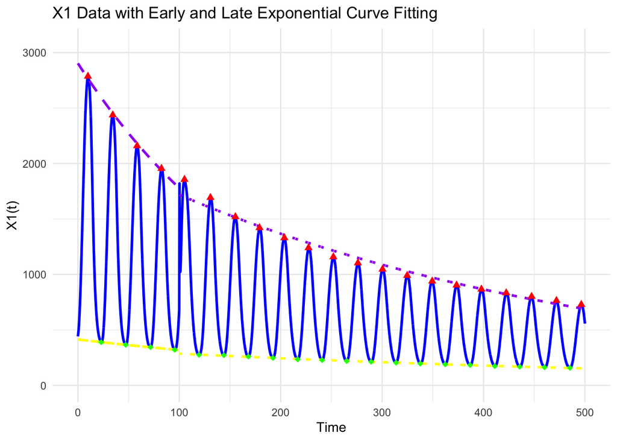

```r
# Generate exponential curves for early and late segments
max_exp_curve_early <- A_max_early * exp(-eta_max_early * time_early)
min_exp_curve_early <- A_min_early * exp(-eta_min_early * time_early)

max_exp_curve_late <- A_max_late * exp(-eta_max_late * time_late)
min_exp_curve_late <- A_min_late * exp(-eta_min_late * time_late)

# Convert data to data frames for ggplot
df_exp_curve_early <- data.frame(Time = time_early, MaxExpCurve = max_exp_curve_early, MinExpCurve = min_exp_curve_early)
df_exp_curve_late <- data.frame(Time = time_late, MaxExpCurve = max_exp_curve_late, MinExpCurve = min_exp_curve_late)

# Peaks and valleys of the original data
df_peaks <- data.frame(Time = t_peaks, Value = y_peaks)
df_valleys <- data.frame(Time = t_valleys, Value = y_valleys)

# Plot the original data and the fitted exponential curves
ggplot(df_MC, aes(x = Time, y = X1)) +
  geom_line(color = "blue", size = 1) +  # original data
  geom_line(data = df_exp_curve_early, aes(x = Time, y = MaxExpCurve), color = "purple", size = 1, linetype = "dashed") +  # Early segment max exponential curve
  geom_line(data = df_exp_curve_early, aes(x = Time, y = MinExpCurve), color = "yellow", size = 1, linetype = "dashed") +  # Early segment min exponential curve
  geom_line(data = df_exp_curve_late, aes(x = Time, y = MaxExpCurve), color = "purple", size = 1, linetype = "dotted") +  # late segment min exponential curve
  geom_line(data = df_exp_curve_late, aes(x = Time, y = MinExpCurve), color = "yellow", size = 1, linetype = "dotted") +  # late segment min exponential curve
  geom_point(data = df_peaks, aes(x = Time, y = Value), color = "red", size = 2, shape = 17) +  # Red points marking peaks
  geom_point(data = df_valleys, aes(x = Time, y = Value), color = "green", size = 2, shape = 18) +  # Green points marking valleys
  labs(title = "X1 Data with Early and Late Exponential Curve Fitting",
       x = "Time",
       y = "X1(t)") +
  theme_minimal() +
  scale_y_continuous(limits = c(0, max(X1) * 1.1))  # Adjust y-axis range to better display data
```

now calculate omega for time <100 and time>=100

```r
# For time < 100
# Calculate Delta and omega for early segment (time < 100)
Delta_early <- t_peaks_early[2] - t_peaks_early[1]  # Assuming the first two peaks are used
omega_early <- 2 * pi / Delta_early

# For time >= 100
# Calculate Delta and omega for late segment (time >= 100)
Delta_late <- t_peaks_late[2] - t_peaks_late[1]  # Assuming the first two peaks in the late segment are used
omega_late <- 2 * pi / Delta_late

# Print results
cat("For time < 100:\n")
```

```
## For time < 100:
```

```r
cat("Delta_early:", Delta_early, "\n")
```

```
## Delta_early: 24.5
```

```r
cat("omega_early:", omega_early, "\n\n")
```

```
## omega_early: 0.2564565
```

```r
cat("For time >= 100:\n")
```

```
## For time >= 100:
```

```r
cat("Delta_late:", Delta_late, "\n")
```

```
## Delta_late: 25.6
```

```r
cat("omega_late:", omega_late, "\n")
```

```
## omega_late: 0.2454369
```

```r
#initial meeting model function
asym_model_function <- function(t, A_max, eta_max, A_min, eta_min, omega, phi_j) {

  A_max_t <- A_max * exp(-eta_max * t)
  A_min_t <- A_min * exp(-eta_min * t)

  result <- 0.5 * (A_max_t + A_min_t) + 0.5 * (A_max_t - A_min_t) * cos(omega * t + phi_j)
  return(result)
}
# sigma = 10
# #simulate data for early segment
# t <- seq(0, 100, by = 0.1)
# early_true_params <- c(2800,0.005, 430,0.0025,0.25,0) #I'm not sure, just guess the true parameters:)
# early_true_params[2]
# early_y_sim <- asym_model_function(t,early_true_params[1],early_true_params[2],early_true_params[3],early_true_params[4],
#                                    early_true_params[5], early_true_params[6]) + rnorm(length(t), mean = 0, sd = sigma0)
# plot(t,early_y_sim,type = "l")
```

Detrending the Data (Exponential Method)

```r
# # Define detrending function using exponential method
# detrend_exponential <- function(time, data_column) {
#   # Fit an exponential model
#   trend_model_exp <- lm(log(data_column) ~ time)
#
#   # Detrend the data by subtracting the fitted exponential trend
#   detrended_data <- data_column - exp(fitted(trend_model_exp))
#
#   return(detrended_data)
# }
#
# # Apply detrending to each column
# detrended_X1 <- detrend_exponential(df_MC$Time, df_MC$X1)
# detrended_X2 <- detrend_exponential(df_MC$Time, df_MC$X2)
# detrended_X3 <- detrend_exponential(df_MC$Time, df_MC$X3)
# detrended_X4 <- detrend_exponential(df_MC$Time, df_MC$X4)
#
# # Plot detrended data
# plot(df_MC$Time, detrended_X1, type = "l", col = "blue", xlab = "Time", ylab = "Detrended Values",
#      main = "Detrended X1, X2, X3, X4 (Exponential)")
# lines(df_MC$Time, detrended_X2, type = "l", col = "green")
# lines(df_MC$Time, detrended_X3, type = "l", col = "red")
# lines(df_MC$Time, detrended_X4, type = "l", col = "purple")
#
# legend("topright", legend = c("X1", "X2", "X3", "X4"), col = c("blue", "green", "red", "purple"), lty = 1, cex = 0.8)
```

Spline Smooth

```r
# # Spline smoothing for detrended data
# spline_detrend_X1 <- predict(smooth.spline(df_MC$Time, detrended_X1))
# spline_detrend_X2 <- predict(smooth.spline(df_MC$Time, detrended_X2))
# spline_detrend_X3 <- predict(smooth.spline(df_MC$Time, detrended_X3))
# spline_detrend_X4 <- predict(smooth.spline(df_MC$Time, detrended_X4))
#
# # Plot the spline-smoothed data
# plot(df_MC$Time, spline_detrend_X1$y, type = "l", col = "red", lwd = 2,
#      xlab = "Time", ylab = "Values", main = "Detrended Splines",
#      ylim = range(c(spline_detrend_X1$y, spline_detrend_X2$y, spline_detrend_X3$y, spline_detrend_X4)))
# lines(df_MC$Time, spline_detrend_X2$y, col = "blue", lwd = 2)
# lines(df_MC$Time, spline_detrend_X3$y, col = "green", lwd = 2)
# lines(df_MC$Time, spline_detrend_X4$y, col = "purple", lwd = 2)
#
# legend("topright", legend = c("spline_detrend_X1", "spline_detrend_X2", "spline_detrend_X3", "spline_detrend_X4"),
#        col = c("red", "blue", "green", "purple"), lwd = 2)
```

Nonlinear Least Squares Model Fitting with Weights ##time specific

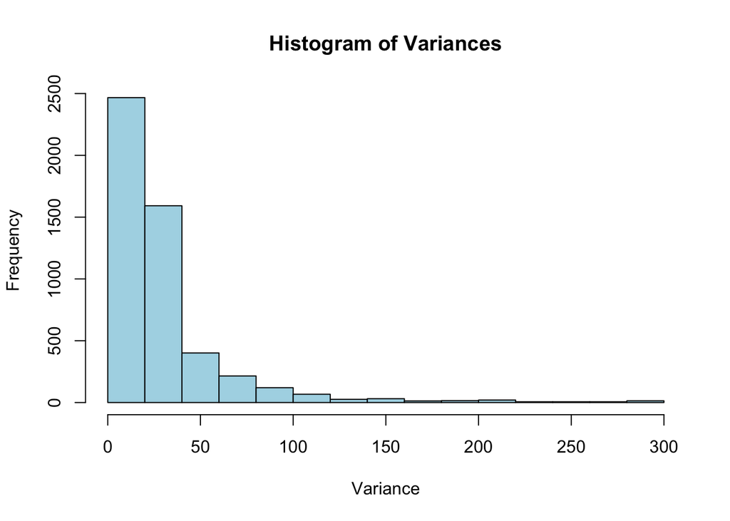

```r
# Define the model function
model_function <- function(t, A, gamma, omega, phi, y_shift) {
  A * exp(-gamma * t ) * cos(omega * t + phi) + y_shift
}
# Function to calculate variance at each time point
calculate_variance <- function(replicates) {
  n <- nrow(replicates)
  mean_vals <- rowMeans(replicates)  # Mean for each time point
  variance <- rowSums((replicates - mean_vals)^2) / (n - 1)  # Variance formula
  return(variance)
}
# Weighted nonlinear least squares estimation
weighted_nls <- function(t, replicates, initial_params) {
  variances <- calculate_variance(replicates)  # Variance at each time point

  # Fit the model using nlsLM
  fit <- nlsLM(y ~ model_function(t, A, gamma, omega, phi, y_shift),
               start = initial_params,
               data = list(t = t, y = rowMeans(replicates)),
               weights = 1 / variances)  # Weight by the inverse of variances
  return(fit)
}
# Use data from replicates for fitting
replicates <- df_MC[, c("X1", "X2", "X3", "X4")]
# Calculate variance
variances <- calculate_variance(replicates)
hist(variances, main = "Histogram of Variances",
     xlab = "Variance",
     ylab = "Frequency",
     col = "lightblue",
     border = "black")
```

```r
# Initial parameter estimates
```